# 『完全独習 統計学入門』

@anemptyarchive

2023-01-20 18:59:26

【編集履歴】

- 2023.01.20：初稿完成

# 第6講 標準偏差(S.D.)でハイリスク・ハイリターン(シャープレシオ)も理解できる

前講では、標準偏差をボラティリティとして株の収益率を比較しました。この講では、標準偏差を使ってシャープレシオを計算して金融商品を比較します。

利用するパッケージを読み込みます。

```r
# 利用パッケージ
library(tidyverse)
library(magick)
```

この記事では、基本的に`パッケージ名::関数名()`の記法を使うので、パッケージを読み込む必要はありません。ただし、作図コードがごちゃごちゃしないようにパッケージ名を省略しているため`ggplot2`を読み込む必要があります。  
また、ネイティブパイプ演算子`|>`を使っています。`magrittr`パッケージのパイプ演算子`%>%`に置き換えても処理できますが、その場合は`magrittr`も読み込む必要があります。

## 6-1 ハイリスク・ハイリターンとローリスク・ローリターン

まずは、データを読み込んで、グラフで確認します。

図表6-1のデータセットをデータフレームとして作成します。

```r
# データを作成:(図表6-1)
revenue_df_wide <- tibble::tibble(
  year = 1988:1995,
  A = c(13.2, 20.9, -6.9, 35.6, 8.9, 12.5, -1.7, 31.1),
  B = c(7.7, 9.5, 3.7, 17.2, 7.9, 10.3, -3.7, 15.6),
  C = c(7.3, 9, 8.1, 5.9, 3.3, 2.6, 3.8, 5.4),
  D = c(7.4, 8.2, 7.9, 7.1, 4.2, 3.3, 3, 4.9)
)
revenue_df_wide
```

```
## # A tibble: 8 × 5
##    year     A     B     C     D
##   <int> <dbl> <dbl> <dbl> <dbl>
## 1  1988  13.2   7.7   7.3   7.4
## 2  1989  20.9   9.5   9     8.2
## 3  1990  -6.9   3.7   8.1   7.9
## 4  1991  35.6  17.2   5.9   7.1
## 5  1992   8.9   7.9   3.3   4.2
## 6  1993  12.5  10.3   2.6   3.3
## 7  1994  -1.7  -3.7   3.8   3
## 8  1995  31.1  15.6   5.4   4.9
```

8年分の収益実績です。

作図用に、各商品の収益率のデータ(列)を1列にまとめます。

```r
# 縦型のデータフレームに変換
revenue_df <- revenue_df_wide |>
  tidyr::pivot_longer(
    cols = !year,
    names_to = "name",
    names_ptypes = list(name = factor()),
    values_to = "revenue_rate"
  )
revenue_df
```

```
## # A tibble: 32 × 3
##     year name  revenue_rate
##    <int> <fct>        <dbl>
##  1  1988 A             13.2
##  2  1988 B              7.7
##  3  1988 C              7.3
##  4  1988 D              7.4
##  5  1989 A             20.9
##  6  1989 B              9.5
##  7  1989 C              9
##  8  1989 D              8.2
##  9  1990 A             -6.9
## 10  1990 B              3.7
## # … with 22 more rows
```

`pivot_longer()`で横型のデータフレームを縦型に変換します。`cols`引数に変換する列(変換しない列を指定する場合は頭に`!`を付けます)、`names_to`引数に「現在の列名」を格納する新たな列の名前、`values_to`引数に「現在の各列の値」を格納する新たな列の名前を指定します。また、`names_ptypes`(または`names_transform`)引数で格納後の型を指定できます。

商品ごとに標準偏差と平均値を計算します。

```r
# 標準偏差と平均値を計算
stat_df <- revenue_df |>
  dplyr::group_by(name) |> # 商品ごとの計算用
  dplyr::summarise(
    sd = sd(revenue_rate),
    mean = mean(revenue_rate),
    .groups = "drop"
  )
stat_df
```

```
## # A tibble: 4 × 3
##   name     sd  mean
##   <fct> <dbl> <dbl>
## 1 A     14.7  14.2
## 2 B      6.58  8.52
## 3 C      2.34  5.68
## 4 D      2.13  5.75
```

商品ごとに(`name`列で)グループ化して、`summarise()`を使って標本標準偏差(不偏標準偏差)と標本平均を計算します。`summarise()`を使って計算すると、計算に利用した行が集約されます(行数が変化します)。

標準偏差を説明変数、平均値を被説明変数として、回帰係数を計算します。

```r
# 回帰係数を計算
res <- lm(stat_df[["mean"]]~stat_df[["sd"]])

# 傾きと切片を取得
a <- res[["coefficients"]][2] # 傾き
b <- res[["coefficients"]][1] # 切片

# names属性を削除
names(a) <- NULL
names(b) <- NULL
a; b
```

```
## [1] 0.6790496
```

```
## [1] 4.16055
```

`lm(被説明変数~説明変数)`で回帰係数を計算できます。  
`lm()`の出力の`"coefficients"`から回帰直線の傾き$a$と切片$b$を取り出します。

回帰直線を計算します。

```r
# x軸の最大値を設定
x_max <- ceiling(max(stat_df[["sd"]]))+1

# 回帰直線を計算
regression_df <- tibble::tibble(
  x = seq(from = 0, to = x_max, by = 0.1),
  y = a * x + b
)
regression_df
```

```
## # A tibble: 161 × 2
##        x     y
##    <dbl> <dbl>
##  1   0    4.16
##  2   0.1  4.23
##  3   0.2  4.30
##  4   0.3  4.36
##  5   0.4  4.43
##  6   0.5  4.50
##  7   0.6  4.57
##  8   0.7  4.64
##  9   0.8  4.70
## 10   0.9  4.77
## # … with 151 more rows
```

作図用のx軸の値$x$を作成して、y軸の値$y = a x + b$を計算します。

リスク(標準偏差)とリターン(平均値)の関係に回帰直線を重ねたグラフを作成します。

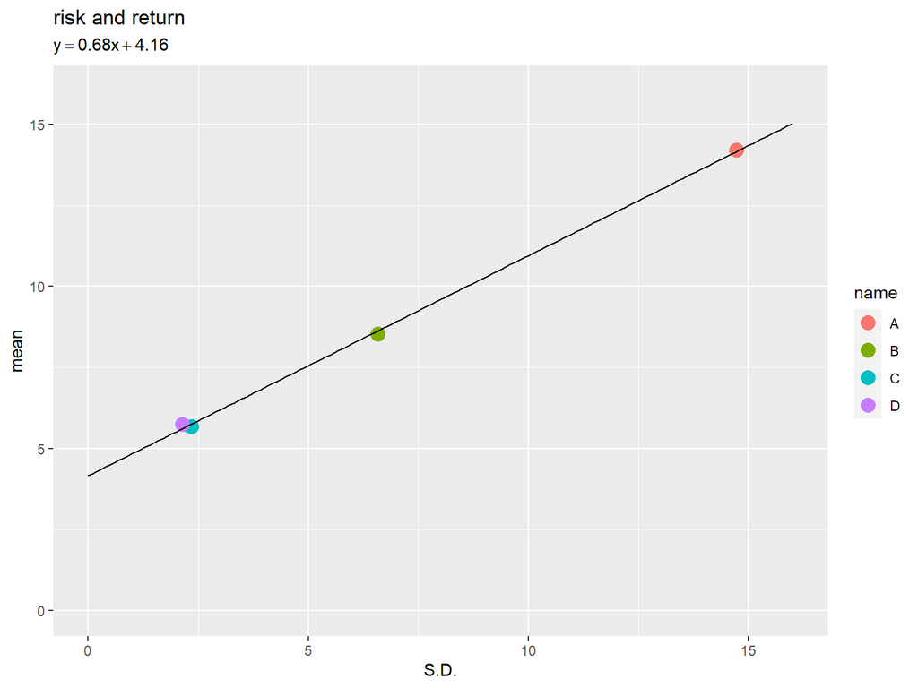

```r
# y軸の最大値を設定
y_max <- ceiling(max(regression_df[["y"]]))

# タイトル用の文字列を作成
regression_label <- paste0("y==", round(a, digits = 2), "*x+", round(b, digits = 2))

# データと回帰直線を作図
ggplot() +
  geom_point(data = stat_df,
             mapping = aes(x = sd, y = mean, color = name),
             size = 4) + # データ
  geom_line(data = regression_df,
            mapping = aes(x = x, y = y)) + # 回帰直線
  coord_cartesian(ylim = c(0, y_max)) + # 描画範囲
  labs(title = "risk and return",
       subtitle = parse(text = regression_label),
       x = "S.D.", y = "mean")
```

4つの商品(データ)を説明できる直線を引けました。

## 6-3 金融商品の優劣を測る数値・シャープレシオ

次は、シャープレシオを計算して、グラフを作成します。

図表6-6のデータセットをデータフレームとして作成します。

```r
# 日本国債の利回りを設定:(図表6-6)
JGB <- 3.4

# シャープレシオを計算
sharpe_df <- tibble::tibble(
  id = 1:7,
  name = c("nissei", "diichi", "sumitomo", "meiji", "asahi", "mitsui", "yasuda"),
  mean = c(4, 4.69, 4.62, 4.8, 5.41, 6.49, 4.85),
  sd = c(5.48, 4.47, 5.59, 4.28, 5.64, 4.64, 6.43)
) |> # 値を格納
  dplyr::mutate(
    sharpe_ratio = (mean - JGB) / sd,
    rank = dplyr::row_number(-sharpe_ratio)
  ) |>
  dplyr::arrange(rank) |>
  dplyr::mutate(
    name = factor(name, levels = name) # 順位に応じて因子レベルを設定
  )
sharpe_df
```

```
## # A tibble: 7 × 6
##      id name      mean    sd sharpe_ratio  rank
##   <int> <fct>    <dbl> <dbl>        <dbl> <int>
## 1     6 mitsui    6.49  4.64        0.666     1
## 2     5 asahi     5.41  5.64        0.356     2
## 3     4 meiji     4.8   4.28        0.327     3
## 4     2 diichi    4.69  4.47        0.289     4
## 5     7 yasuda    4.85  6.43        0.226     5
## 6     3 sumitomo  4.62  5.59        0.218     6
## 7     1 nissei    4     5.48        0.109     7
```

国債の利回りを`JGB`として値を指定します。

会社ごとの平均値$\bar{x}$と標準偏差$S$をデータフレームに格納します。  
会社ごとにシャープレシオを$\frac{\bar{x} - \mathrm{JGB}}{S}$で計算します。  
シャープレシオの値に応じて`row_number()`で順位を付けます。`row_number()`は昇順に行番号を割り当てるので、シャープレシオ列の値に`-`を付けることで大小関係を反転させて、降順に値を割り当てます。

順位に応じて`arrange()`で行を並べ替えて、作図時の色付けや凡例の並びを調整するために、会社列を因子型にして因子レベルを設定します。(装飾用の処理なので省略できます。)

シャープレシオ(角度のマーク)を描画するためのデータフレームを作成します。(装飾用の処理です。)

```r
# シャープレシオの
angle_df <- sharpe_df |>
  dplyr::group_by(name) |> # 商品ごとの計算用
  dplyr::summarise(
    theta = seq(from = 0, to = atan(sharpe_ratio), by = 0.01), # 角度(ラジアン)を作成
    x = cos(theta) * (id*0.05+0.1),
    y = sin(theta) * (id*0.05+0.1) + JGB,
    .groups = "drop"
  )
angle_df
```

```
## # A tibble: 211 × 4
##    name   theta     x     y
##    <fct>  <dbl> <dbl> <dbl>
##  1 mitsui  0    0.4    3.4
##  2 mitsui  0.01 0.400  3.40
##  3 mitsui  0.02 0.400  3.41
##  4 mitsui  0.03 0.400  3.41
##  5 mitsui  0.04 0.400  3.42
##  6 mitsui  0.05 0.400  3.42
##  7 mitsui  0.06 0.399  3.42
##  8 mitsui  0.07 0.399  3.43
##  9 mitsui  0.08 0.399  3.43
## 10 mitsui  0.09 0.398  3.44
## # … with 201 more rows
```

逆タンジェント関数`atan()`でシャープレシオ(傾き)から弧度法における角度(ラジアン)を作成して、コサイン関数`cos()`でx軸の値、サイン関数`sin()`でy軸の値を計算します。さらに、y軸の値に国債の利回り`JGB`を加えます。`(id*0.05+0.1)`はサイズ調整用の値です。

リスクとリターンの関係にシャープレシオを重ねたグラフを作成します。

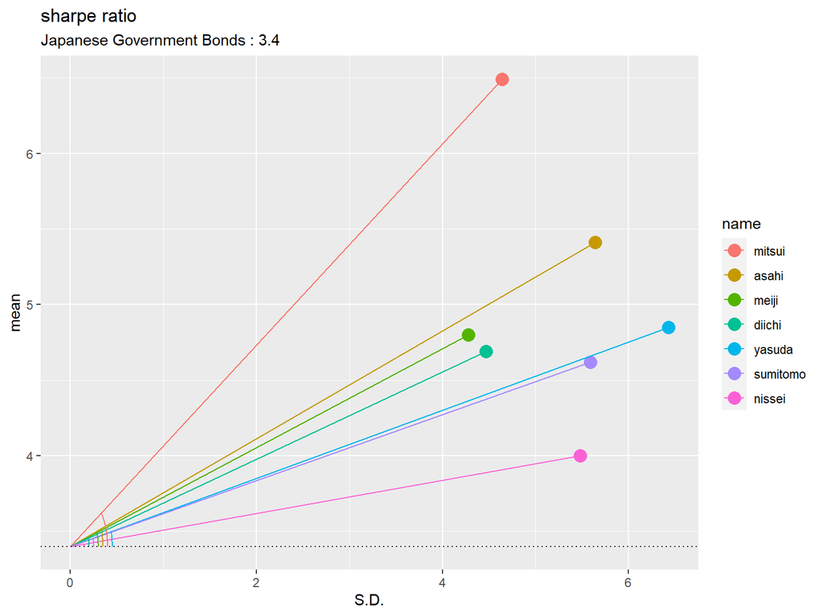

```r
# シャープレシオを作図
ggplot() +
  geom_point(data = sharpe_df,
             mapping = aes(x = sd, y = mean, color = name),
             size = 4) + # データ
  geom_segment(data = sharpe_df,
               mapping = aes(x = 0, y = JGB, xend = sd, yend = mean, color = name)) + # データ線
  geom_path(data = angle_df, mapping = aes(x = x, y = y, color = name)) + # シャープレシオ
  geom_hline(yintercept = JGB, linetype = "dotted") + # 国債の利回り
  labs(title = "sharpe ratio",
       subtitle = paste0("Japanese Government Bonds : ", JGB),
       x = "S.D.", y = "mean")
```

国債の利回りの点と、各商品の点を結ぶ線分を`geom_segment()`で描画します。`x, y`引数に始点の座標(国債の利回り)、`xend, yend`引数に終点の座標(各会社の実績)を指定します。  
国債の利回りを示す水平線を`geom_hline()`で描画します。`yintercept`引数に国債の利回りを指定します。  
水平線と線分の角度(傾き)を示す孤(角度のマーク)を`geom_path()`で描画します。

平均収益率(y軸の値)の大小ではなく、シャープレシオ(角度)の大きさで商品を評価できます。

この講では、標準偏差を利用してシャープレシオを比較しました。

# 参考書籍

- 小島寛之『完全独習 統計学入門』ダイヤモンド社,2006年.